# AV2Simulado

## Árvore Geradora Mínima e Caminho Mínimo em Grafos

Vamos entender de forma simples e visual dois conceitos essenciais em grafos: **árvore geradora mínima** e **caminho mínimo**. Ambos são fundamentais para resolver problemas de conectividade e otimização em redes, logística, energia, transporte e muito mais.

### Árvore Geradora Mínima

Imagine que você precisa conectar várias cidades (vértices) usando estradas (arestas), mas quer gastar o mínimo possível e garantir que todas estejam conectadas, sem formar voltas (ciclos). A **árvore geradora mínima** é exatamente isso: um subgrafo que conecta todos os vértices com o menor custo total possível, sem ciclos, usando exatamente $n-1$ arestas (onde $n$ é o número de vértices).

- **Exemplo prático:** Instalar cabos entre cidades gastando o mínimo possível.
- **Principais algoritmos:**
  - **Kruskal:** Escolhe sempre a estrada mais barata que não forma ciclo, até conectar tudo.
  - **Prim:** Começa em um vértice e vai conectando o mais próximo, sempre escolhendo a estrada mais barata para expandir a rede.

### Caminho Mínimo

Agora, suponha que você quer ir de uma cidade até outra, passando pelo menor número de estradas ou gastando o menor custo possível. O **caminho mínimo** é a rota mais curta (em número de arestas ou em custo total) entre dois vértices.

- **Exemplo prático:** Encontrar a rota mais curta ou mais barata entre dois pontos de uma cidade.
- **Principais algoritmos:**
  - **Busca em Largura (BFS):** Para grafos sem pesos, encontra o caminho com menos arestas.
  - **Dijkstra:** Para grafos com pesos positivos, encontra o caminho de menor custo.
  - **Bellman-Ford:** Para grafos com pesos negativos (mas sem ciclos negativos).

### Relação e Aplicação

- **Árvore geradora mínima** resolve o problema de conectar todos os pontos de uma rede com o menor custo total, sem redundâncias.
- **Caminho mínimo** resolve o problema de ir de um ponto a outro da forma mais eficiente possível.

Ambos são usados para garantir eficiência, economia e conectividade em sistemas reais. Saber aplicar cada conceito no contexto certo é fundamental para otimizar redes e rotas!

### Questão 01 - Arvore Geradora Mínima

Uma empresa de energia deseja instalar cabos para conectar 7 bairros de forma eficiente. A rede deve ser construída de modo que:

Todos os bairros estejam conectados direta ou indiretamente. Não existam ciclos na rede. A remoção de qualquer cabo desconecte a rede. Com base nessas condições e nas definições de árvores em grafos, qual é o número mínimo de cabos necessários para conectar todos os bairros?

```python
## Questão 1
import networkx as nx

n_bairros = 7
# Em uma árvore com n vértices, o número de arestas é n-1
arestas_necessarias = n_bairros - 1
print(f"Número de cabos necessários: {arestas_necessarias}")
```

```
Número de cabos necessários: 6
```

#### Explicação Detalhada sobre Árvore

A situação apresentada corresponde à definição de uma **árvore** em Teoria dos Grafos. Vamos analisar cada condição:

1. **Todos os bairros devem estar conectados direta ou indiretamente.**  
   Isso significa que o grafo deve ser **conexo**: é possível ir de qualquer bairro a qualquer outro, mesmo que seja passando por outros bairros intermediários.
2. **Não pode haver ciclos na rede de cabos.**  
   Um ciclo ocorre quando é possível sair de um bairro, passar por outros e retornar ao bairro inicial sem repetir arestas. A ausência de ciclos caracteriza um grafo **acíclico**.
3. **Se qualquer cabo for removido, a rede ficará desconectada.**  
   Isso significa que todas as conexões são essenciais para manter a rede unida. Em outras palavras, o grafo é **minimamente conexo**: não há arestas redundantes.

Essas três propriedades juntas definem uma **árvore**. Em uma árvore com $n$ vértices (neste caso, bairros), sempre existem exatamente $n-1$ arestas (cabos). Isso é uma propriedade fundamental das árvores em grafos.

**Aplicando ao problema:**

- Temos $n = 7$ bairros.
- Logo, o número mínimo de cabos necessários é $n-1 = 6$.

Se usarmos menos de 6 cabos, não conseguiremos conectar todos os bairros. Se usarmos mais de 6 cabos, obrigatoriamente haverá pelo menos um ciclo, o que viola a condição 2.

Portanto, a resposta correta é **6 cabos**.

### Questão 2: Busca em Largura (BFS)

Uma empresa de energia deseja monitorar o fornecimento em uma rede de subestações, representada por um grafo não direcionado. Os vértices são subestações e as arestas representam linhas de transmissão entre elas. Para garantir o monitoramento eficiente, a empresa precisa calcular o vetor de roteamento correto para alcançar todas as subestações a partir de uma subestação inicial, utilizando a Busca em Largura (BFS).

Considere o grafo abaixo, onde as subestações e as linhas são:

1. Subestação X - Subestação Y
2. Subestação X - Subestação Z
3. Subestação Y - Subestação W
4. Subestação Z - Subestação W
5. Subestação Z - Subestação V
6. Subestação W - Subestação U
7. Subestação V - Subestação U

Qual vetor de roteamento, gerado a partir da Subestação X, está correto?

## Busca em Largura (BFS)

A **Busca em Largura** (BFS - *Breadth-First Search*) é um algoritmo utilizado para percorrer ou buscar elementos em grafos (ou árvores). O objetivo é visitar todos os vértices acessíveis a partir de um vértice inicial, explorando primeiro os vizinhos mais próximos antes de avançar para os mais distantes.

### Como funciona a BFS?

1. **Escolha um vértice inicial** e marque-o como visitado.
2. **Coloque o vértice em uma fila**.
3. Enquanto a fila não estiver vazia:
   - Remova o primeiro vértice da fila.
   - Para cada vizinho não visitado desse vértice:
     - Marque o vizinho como visitado.
     - Adicione o vizinho à fila.

### Características

- Garante encontrar o caminho mais curto (menor número de arestas) em grafos não ponderados.
- Utiliza uma **fila** para controlar a ordem de visitação.
- Visita todos os vértices a uma distância antes de avançar para a próxima.

### Exemplo de aplicação

- Encontrar o caminho mais curto entre dois pontos em um mapa.
- Verificar se um grafo é conexo.
- Encontrar todos os vértices a uma certa distância de um ponto.

**Resumo:**  
A BFS é ideal para explorar grafos em "camadas", sendo muito útil para encontrar caminhos mínimos e analisar a estrutura de redes.

```
Passo 0:
  Fila inicial: ['X']
  Visitados: []
  Predecessores: {'X': None}
  Nenhum vértice processado ainda.
```

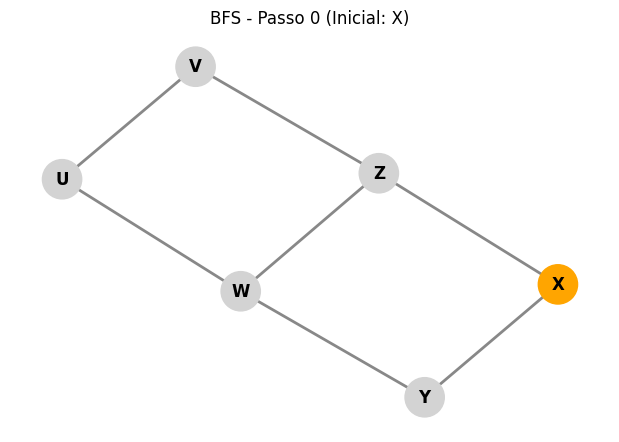

```
Passo 1:
  Fila antes de processar: []
  Visitados até agora: []
  Vértice atual: X
  Predecessores: {'X': None}
```

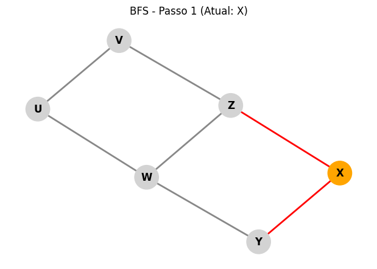

```
  Fila após adicionar vizinhos: ['Y', 'Z']
  Predecessores atualizados: {'X': None, 'Y': 'X', 'Z': 'X'}

Passo 2:
  Fila antes de processar: ['Z']
  Visitados até agora: ['X']
  Vértice atual: Y
  Predecessores: {'X': None, 'Y': 'X', 'Z': 'X'}
```

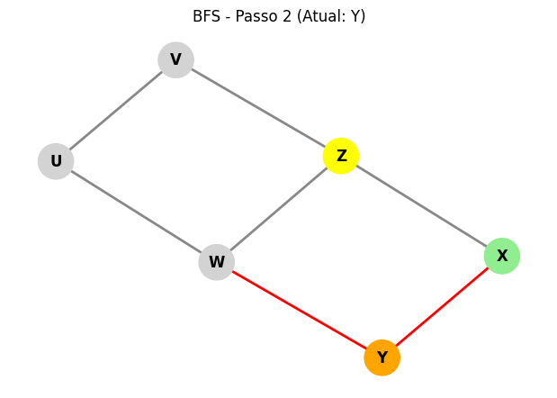

```
  Fila após adicionar vizinhos: ['Z', 'W']
  Predecessores atualizados: {'X': None, 'Y': 'X', 'Z': 'X', 'W': 'Y'}

Passo 3:
  Fila antes de processar: ['W']
  Visitados até agora: ['X', 'Y']
  Vértice atual: Z
  Predecessores: {'X': None, 'Y': 'X', 'Z': 'X', 'W': 'Y'}
```

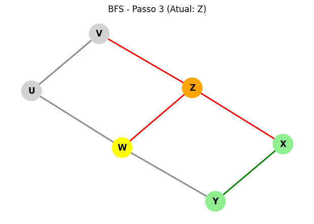

```
  Fila após adicionar vizinhos: ['W', 'V']
  Predecessores atualizados: {'X': None, 'Y': 'X', 'Z': 'X', 'W': 'Y', 'V': 'Z'}

Passo 4:
  Fila antes de processar: ['V']
  Visitados até agora: ['X', 'Y', 'Z']
  Vértice atual: W
  Predecessores: {'X': None, 'Y': 'X', 'Z': 'X', 'W': 'Y', 'V': 'Z'}
```

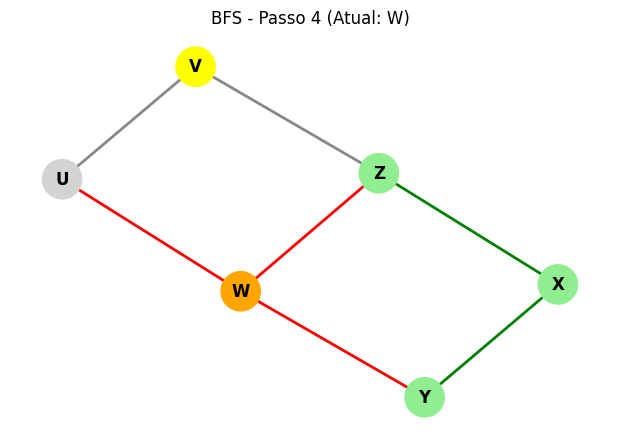

```
  Fila após adicionar vizinhos: ['V', 'U']
  Predecessores atualizados: {'X': None, 'Y': 'X', 'Z': 'X', 'W': 'Y', 'V': 'Z', 'U': 'W'}

Passo 5:
  Fila antes de processar: ['U']
  Visitados até agora: ['X', 'Y', 'Z', 'W']
  Vértice atual: V
  Predecessores: {'X': None, 'Y': 'X', 'Z': 'X', 'W': 'Y', 'V': 'Z', 'U': 'W'}
```

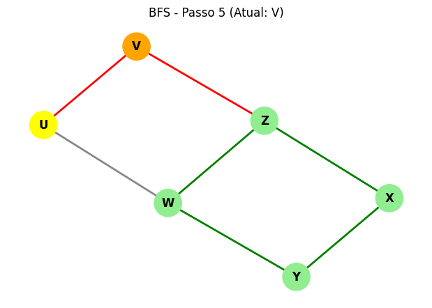

```
  Fila após adicionar vizinhos: ['U']
  Predecessores atualizados: {'X': None, 'Y': 'X', 'Z': 'X', 'W': 'Y', 'V': 'Z', 'U': 'W'}

Passo 6:
  Fila antes de processar: []
  Visitados até agora: ['X', 'Y', 'Z', 'W', 'V']
  Vértice atual: U
  Predecessores: {'X': None, 'Y': 'X', 'Z': 'X', 'W': 'Y', 'V': 'Z', 'U': 'W'}
```

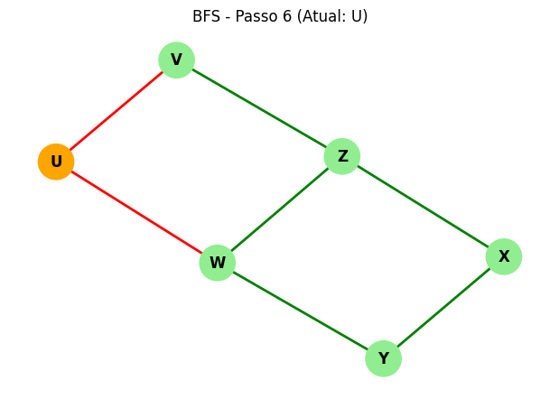

```
  Fila após adicionar vizinhos: []
  Predecessores atualizados: {'X': None, 'Y': 'X', 'Z': 'X', 'W': 'Y', 'V': 'Z', 'U': 'W'}

Vetor de roteamento final: ['X', 'Y', 'Z', 'W', 'V', 'U']
Predecessores finais: {'X': None, 'Y': 'X', 'Z': 'X', 'W': 'Y', 'V': 'Z', 'U': 'W'}
```

```
(['X', 'Y', 'Z', 'W', 'V', 'U'],
 {'X': None, 'Y': 'X', 'Z': 'X', 'W': 'Y', 'V': 'Z', 'U': 'W'})
```

```python
# Resolvendo o vetor de roteamento usando BFS a partir da Subestação X
import networkx as nx

# Criação do grafo
G = nx.Graph()
G.add_edges_from([
    ('X', 'Y'),
    ('X', 'Z'),
    ('Y', 'W'),
    ('Z', 'W'),
    ('Z', 'V'),
    ('W', 'U'),
    ('V', 'U')
])

# BFS a partir da subestação X
from collections import deque
import matplotlib.pyplot as plt

def bfs_routing_vector_verbose(graph, start):
    visitados = set()
    fila = deque([start])
    vetor = []
    predecessor = {start: None}
    passo = 0

    pos = nx.spring_layout(graph, seed=42)  # posição fixa para todos os plots

    print(f"Passo {passo}:")
    print(f"  Fila inicial: {list(fila)}")
    print(f"  Visitados: {vetor}")
    print(f"  Predecessores: {predecessor}")
    print(f"  Nenhum vértice processado ainda.\n")
    plt.figure(figsize=(6,4))
    nx.draw(
        graph, pos, with_labels=True,
        node_color=['orange' if n == start else 'lightgray' for n in graph.nodes],
        node_size=800, font_weight='bold',
        edge_color='#888', width=2
    )
    plt.title(f"BFS - Passo {passo} (Inicial: {start})")
    plt.show()
    passo += 1

    while fila:
        atual = fila.popleft()
        print(f"Passo {passo}:")
        print(f"  Fila antes de processar: {list(fila)}")
        print(f"  Visitados até agora: {vetor}")
        print(f"  Vértice atual: {atual}")
        print(f"  Predecessores: {predecessor}")

        # Cores dos nós
        node_colors = []
        for n in graph.nodes:
            if n == atual:
                node_colors.append('orange')      # atual
            elif n in vetor:
                node_colors.append('lightgreen')  # já visitado
            elif n in fila:
                node_colors.append('yellow')      # na fila
            else:
                node_colors.append('lightgray')   # não visitado

        # Cores das arestas: destaque as arestas do nó atual
        edge_colors = []
        for u, v in graph.edges:
            if (u == atual and v in graph.neighbors(atual)) or (v == atual and u in graph.neighbors(atual)):
                edge_colors.append('red')
            elif u in vetor and v in vetor:
                edge_colors.append('green')
            else:
                edge_colors.append('#888')

        plt.figure(figsize=(6,4))
        nx.draw(
            graph, pos, with_labels=True,
            node_color=node_colors, node_size=800, font_weight='bold',
            edge_color=edge_colors, width=2
        )
        plt.title(f"BFS - Passo {passo} (Atual: {atual})")
        plt.show()

        if atual not in visitados:
            visitados.add(atual)
            vetor.append(atual)
            for vizinho in sorted(graph.neighbors(atual)):
                if vizinho not in visitados and vizinho not in fila:
                    fila.append(vizinho)
                    if vizinho not in predecessor:
                        predecessor[vizinho] = atual
        print(f"  Fila após adicionar vizinhos: {list(fila)}")
        print(f"  Predecessores atualizados: {predecessor}\n")
        passo += 1
    print("Vetor de roteamento final:", vetor)
    print("Predecessores finais:", predecessor)
    return vetor, predecessor

# Executando a versão detalhada
bfs_routing_vector_verbose(G, 'X')
```

#### Explicação Detalhada

A questão pede o vetor de roteamento gerado pela **Busca em Largura (BFS)**, que é um algoritmo para percorrer grafos visitando todos os vértices acessíveis a partir de um vértice inicial, explorando primeiro os vizinhos mais próximos.

No contexto do problema:

- Cada subestação é um vértice.
- Cada linha de transmissão é uma aresta.
- O vetor de roteamento é a ordem em que as subestações são visitadas a partir da subestação inicial (X), seguindo a BFS.

**Como funciona a BFS:**

1. Começa pelo vértice inicial (X), marcando-o como visitado.
2. Visita todos os vizinhos diretos de X (Y e Z).
3. Em seguida, visita os vizinhos dos vizinhos, e assim por diante, sempre explorando primeiro os vértices mais próximos do ponto de partida.
4. O algoritmo garante que cada vértice é visitado apenas uma vez.

**No exemplo acima, o vetor de roteamento pode ser:**  
['X', 'Y', 'Z', 'W', 'V', 'U']

A ordem pode variar dependendo da ordem dos vizinhos, mas sempre segue o princípio de visitar primeiro os vértices mais próximos do inicial.

Portanto, o vetor de roteamento correto é aquele que reflete a ordem de visitação da BFS a partir da subestação inicial.

```
Caminho mais curto de X até U: ['X', 'Y', 'W', 'U']
```

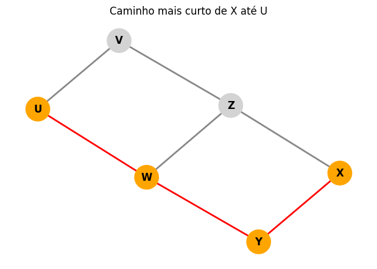

```python
# Exemplo: Encontrando o caminho mais curto entre duas subestações usando BFS (NetworkX)
origem = 'X'
destino = 'U'
caminho_mais_curto = nx.shortest_path(G, source=origem, target=destino)
print(f"Caminho mais curto de {origem} até {destino}: {caminho_mais_curto}")

# Visualizando o caminho encontrado
import matplotlib.pyplot as plt

pos = nx.spring_layout(G, seed=42)
edge_colors = []
for u, v in G.edges:
    if (u, v) in zip(caminho_mais_curto, caminho_mais_curto[1:]) or (v, u) in zip(caminho_mais_curto, caminho_mais_curto[1:]):
        edge_colors.append('red')
    else:
        edge_colors.append('#888')

node_colors = ['orange' if n in caminho_mais_curto else 'lightgray' for n in G.nodes]

plt.figure(figsize=(6,4))
nx.draw(G, pos, with_labels=True, node_color=node_colors, node_size=800, font_weight='bold', edge_color=edge_colors, width=2)
plt.title(f"Caminho mais curto de {origem} até {destino}")
plt.show()
```

#### Exemplo de busca de caminho

No exemplo acima, utilizamos o algoritmo de caminho mais curto do NetworkX (que, em grafos não ponderados, utiliza a Busca em Largura - BFS) para encontrar o caminho mais curto entre a subestação X e a subestação U.

**Caminho encontrado:**  
['X', 'Y', 'W', 'U']

Ou seja, para ir de X até U, o trajeto mais curto passa por Y e W.

**Explicação:**

Portanto, a resposta correta para o caminho mais curto entre X e U é:  
**['X', 'Y', 'W', 'U']**

### Questão 3: Busca em Profundidade (DFS)

Uma empresa de tecnologia deseja analisar a conectividade entre os computadores de sua rede interna. A rede é representada como um grafo, onde os vértices são computadores e as arestas representam conexões diretas entre eles. A empresa quer calcular o vetor de roteamento correto para alcançar todos os computadores a partir de um computador inicial, utilizando a busca em profundidade (DFS).

Considere o grafo abaixo, onde os computadores e as conexões são representados como:

1. Computador A - Computador B
2. Computador A - Computador C
3. Computador B - Computador D
4. Computador C - Computador D
5. Computador C - Computador E
6. Computador D - Computador F
7. Computador E - Computador F

Qual vetor de roteamento, gerado a partir do Computador A, está correto? Mostre o passo a passo da DFS.

## Busca em Profundidade (DFS)

A **Busca em Profundidade** (DFS - *Depth-First Search*) é um algoritmo utilizado para percorrer ou buscar elementos em grafos (ou árvores). O objetivo é explorar o grafo indo o mais fundo possível em cada ramificação antes de retroceder.

### Como funciona a DFS?

1. **Escolha um vértice inicial** e marque-o como visitado.
2. Para cada vizinho não visitado desse vértice:
   - Visite o vizinho e repita o processo recursivamente.
3. Se não houver mais vizinhos não visitados, volte (retroceda) para o vértice anterior e continue a busca.

A DFS pode ser implementada de forma recursiva ou utilizando uma pilha.

### Características

- Explora o grafo em profundidade, indo até o final de cada caminho antes de voltar.
- Utiliza uma **pilha** (explícita ou implícita via recursão) para controlar a ordem de visitação.
- Pode ser usada para detectar ciclos, componentes conexas, caminhos e ordenação topológica.

### Exemplo de aplicação

- Verificar se existe um caminho entre dois vértices.
- Encontrar componentes conexas em grafos.
- Resolver labirintos.
- Ordenação topológica em grafos direcionados acíclicos.

**Resumo:**  
A DFS é ideal para explorar todos os caminhos possíveis a partir de um vértice, sendo muito útil para análise estrutural de grafos e resolução de problemas que exigem percorrer todas as possibilidades.

```
Passo 0:
  Pilha inicial: ['A']
  Visitados: []
  Predecessores: {'A': None}
  Nenhum vértice processado ainda.
```

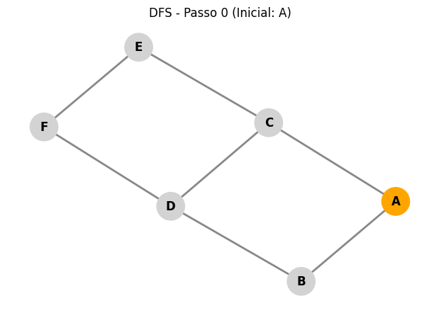

```
Passo 1:
  Pilha: []
  Visitados: []
  Vértice atual: A
  Predecessores: {'A': None}
```

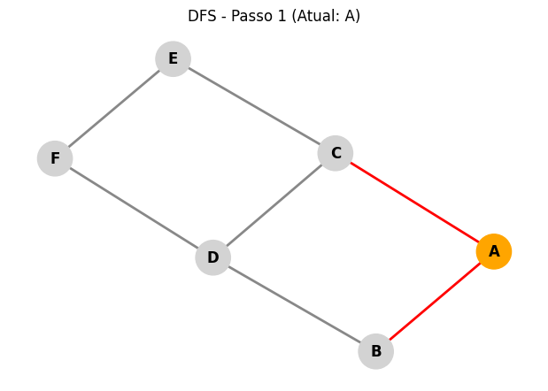

```
  Pilha após adicionar vizinhos: ['C', 'B']
  Predecessores atualizados: {'A': None, 'C': 'A', 'B': 'A'}

Passo 2:
  Pilha: ['C']
  Visitados: ['A']
  Vértice atual: B
  Predecessores: {'A': None, 'C': 'A', 'B': 'A'}
```

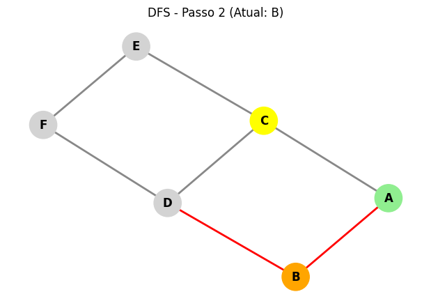

```
  Pilha após adicionar vizinhos: ['C', 'D']
  Predecessores atualizados: {'A': None, 'C': 'A', 'B': 'A', 'D': 'B'}

Passo 3:
  Pilha: ['C']
  Visitados: ['A', 'B']
  Vértice atual: D
  Predecessores: {'A': None, 'C': 'A', 'B': 'A', 'D': 'B'}
```

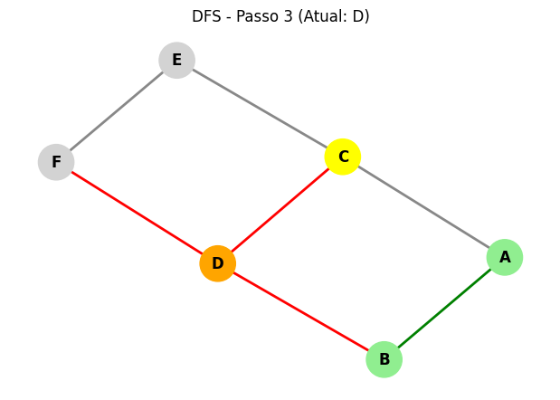

```
  Pilha após adicionar vizinhos: ['C', 'F']
  Predecessores atualizados: {'A': None, 'C': 'A', 'B': 'A', 'D': 'B', 'F': 'D'}

Passo 4:
  Pilha: ['C']
  Visitados: ['A', 'B', 'D']
  Vértice atual: F
  Predecessores: {'A': None, 'C': 'A', 'B': 'A', 'D': 'B', 'F': 'D'}
```

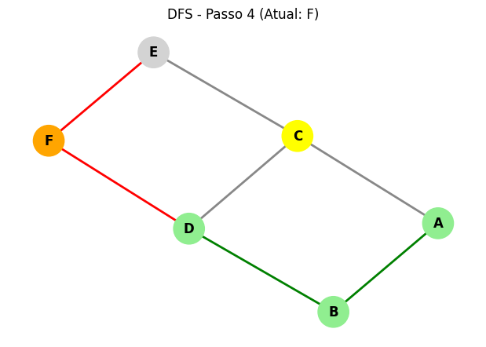

```
  Pilha após adicionar vizinhos: ['C', 'E']
  Predecessores atualizados: {'A': None, 'C': 'A', 'B': 'A', 'D': 'B', 'F': 'D', 'E': 'F'}

Passo 5:
  Pilha: ['C']
  Visitados: ['A', 'B', 'D', 'F']
  Vértice atual: E
  Predecessores: {'A': None, 'C': 'A', 'B': 'A', 'D': 'B', 'F': 'D', 'E': 'F'}
```

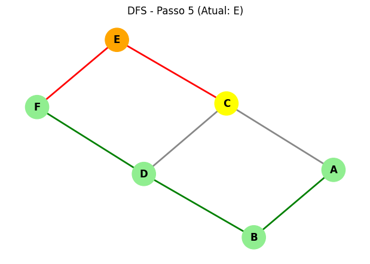

```
  Pilha após adicionar vizinhos: ['C']
  Predecessores atualizados: {'A': None, 'C': 'A', 'B': 'A', 'D': 'B', 'F': 'D', 'E': 'F'}

Passo 6:
  Pilha: []
  Visitados: ['A', 'B', 'D', 'F', 'E']
  Vértice atual: C
  Predecessores: {'A': None, 'C': 'A', 'B': 'A', 'D': 'B', 'F': 'D', 'E': 'F'}
```

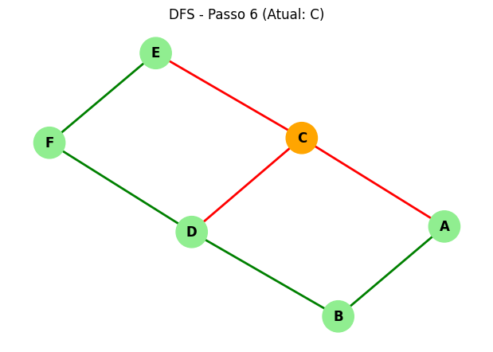

```
  Pilha após adicionar vizinhos: []
  Predecessores atualizados: {'A': None, 'C': 'A', 'B': 'A', 'D': 'B', 'F': 'D', 'E': 'F'}

Vetor de roteamento final (DFS): ['A', 'B', 'D', 'F', 'E', 'C']
Predecessores finais: {'A': None, 'C': 'A', 'B': 'A', 'D': 'B', 'F': 'D', 'E': 'F'}
```

```
(['A', 'B', 'D', 'F', 'E', 'C'],
 {'A': None, 'C': 'A', 'B': 'A', 'D': 'B', 'F': 'D', 'E': 'F'})
```

```python
# Passo a passo da DFS com visualização

import networkx as nx
import matplotlib.pyplot as plt

G_dfs = nx.Graph()
G_dfs.add_edges_from([
    ('A', 'B'),
    ('A', 'C'),
    ('B', 'D'),
    ('C', 'D'),
    ('C', 'E'),
    ('D', 'F'),
    ('E', 'F')
])

def dfs_routing_vector_verbose(graph, start):
    visitados = set()
    vetor = []
    pilha = [start]
    predecessor = {start: None}
    passo = 0
    pos = nx.spring_layout(graph, seed=42)

    print(f"Passo {passo}:")
    print(f"  Pilha inicial: {pilha}")
    print(f"  Visitados: {vetor}")
    print(f"  Predecessores: {predecessor}")
    print(f"  Nenhum vértice processado ainda.\n")
    plt.figure(figsize=(6,4))
    nx.draw(
        graph, pos, with_labels=True,
        node_color=['orange' if n == start else 'lightgray' for n in graph.nodes],
        node_size=800, font_weight='bold',
        edge_color='#888', width=2
    )
    plt.title(f"DFS - Passo {passo} (Inicial: {start})")
    plt.show()
    passo += 1

    while pilha:
        atual = pilha.pop()
        if atual not in visitados:
            print(f"Passo {passo}:")
            print(f"  Pilha: {pilha}")
            print(f"  Visitados: {vetor}")
            print(f"  Vértice atual: {atual}")
            print(f"  Predecessores: {predecessor}")

            # Cores dos nós
            node_colors = []
            for n in graph.nodes:
                if n == atual:
                    node_colors.append('orange')
                elif n in vetor:
                    node_colors.append('lightgreen')
                elif n in pilha:
                    node_colors.append('yellow')
                else:
                    node_colors.append('lightgray')

            # Cores das arestas: destaque as arestas do nó atual
            edge_colors = []
            for u, v in graph.edges:
                if (u == atual and v in graph.neighbors(atual)) or (v == atual and u in graph.neighbors(atual)):
                    edge_colors.append('red')
                elif u in vetor and v in vetor:
                    edge_colors.append('green')
                else:
                    edge_colors.append('#888')

            plt.figure(figsize=(6,4))
            nx.draw(
                graph, pos, with_labels=True,
                node_color=node_colors, node_size=800, font_weight='bold',
                edge_color=edge_colors, width=2
            )
            plt.title(f"DFS - Passo {passo} (Atual: {atual})")
            plt.show()

            visitados.add(atual)
            vetor.append(atual)
            # Adiciona vizinhos não visitados na pilha (ordem reversa para manter ordem alfabética)
            for vizinho in sorted(graph.neighbors(atual), reverse=True):
                if vizinho not in visitados and vizinho not in pilha:
                    pilha.append(vizinho)
                    if vizinho not in predecessor:
                        predecessor[vizinho] = atual
            print(f"  Pilha após adicionar vizinhos: {pilha}")
            print(f"  Predecessores atualizados: {predecessor}\n")
            passo += 1
    print("Vetor de roteamento final (DFS):", vetor)
    print("Predecessores finais:", predecessor)
    return vetor, predecessor

# Executando a versão detalhada
dfs_routing_vector_verbose(G_dfs, 'A')
```

### Explicação

A busca em profundidade (DFS) explora o grafo indo o mais fundo possível em cada ramificação antes de retroceder. O vetor de roteamento mostra a ordem em que os computadores são visitados a partir do computador inicial (A).

No exemplo acima, o passo a passo mostra a pilha, os visitados e o vértice atual em cada etapa, além de uma visualização do grafo. O vetor final corresponde à ordem de visitação da DFS.

```
Caminho encontrado de A até F usando DFS: ['A', 'B', 'D', 'C', 'E', 'F']
```

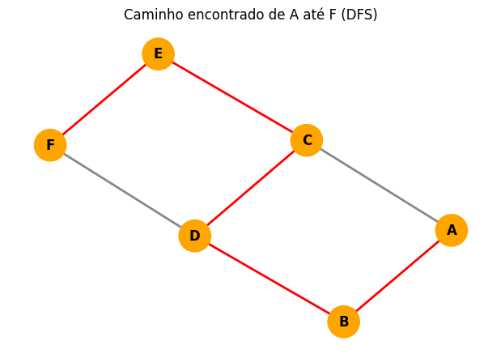

```python
# Exemplo: Encontrando um caminho entre dois computadores usando DFS (NetworkX)
origem = 'A'
destino = 'F'
caminho_dfs = list(nx.dfs_edges(G_dfs, source=origem))
# Reconstruindo o caminho a partir das arestas DFS
def reconstruir_caminho(edges, origem, destino):
    caminho = [origem]
    atual = origem
    while atual != destino:
        for u, v in edges:
            if u == atual and v not in caminho:
                caminho.append(v)
                atual = v
                break
        else:
            break
    return caminho

caminho_encontrado = reconstruir_caminho(caminho_dfs, origem, destino)
print(f"Caminho encontrado de {origem} até {destino} usando DFS:", caminho_encontrado)

# Visualizando o caminho encontrado
import matplotlib.pyplot as plt

pos = nx.spring_layout(G_dfs, seed=42)
edge_colors = []
for u, v in G_dfs.edges:
    if (u, v) in zip(caminho_encontrado, caminho_encontrado[1:]) or (v, u) in zip(caminho_encontrado, caminho_encontrado[1:]):
        edge_colors.append('red')
    else:
        edge_colors.append('#888')

node_colors = ['orange' if n in caminho_encontrado else 'lightgray' for n in G_dfs.nodes]

plt.figure(figsize=(6,4))
nx.draw(G_dfs, pos, with_labels=True, node_color=node_colors, node_size=800, font_weight='bold', edge_color=edge_colors, width=2)
plt.title(f"Caminho encontrado de {origem} até {destino} (DFS)")
plt.show()
```

### Exemplo de busca de caminho

No exemplo acima, utilizamos o algoritmo de busca em profundidade do NetworkX (DFS) para encontrar um caminho entre o Computador A e o Computador F.

**Explicação:**

- O DFS explora o grafo indo o mais fundo possível em cada ramificação antes de retroceder.
- O caminho é encontrado seguindo as arestas do grafo na ordem em que foram exploradas pelo DFS.
- O caminho é destacado em vermelho no grafo plotado.

### Questão 4: Árvore Geradora Mínima com Kruskal (grafo ponderado)

Considere o grafo ponderado abaixo, onde os vértices representam bairros e as arestas representam ruas com seus respectivos custos de pavimentação:

1. Bairro A - Bairro B: 4
2. Bairro A - Bairro C: 2
3. Bairro B - Bairro C: 6
4. Bairro B - Bairro D: 3
5. Bairro C - Bairro D: 5
6. Bairro C - Bairro E: 8
7. Bairro D - Bairro E: 7

Utilizando o algoritmo de Kruskal para encontrar a árvore geradora mínima, qual é o custo total mínimo para conectar todos os bairros? Mostre o passo a passo da construção.

## Algoritmo de Kruskal

O **algoritmo de Kruskal** é um método utilizado para encontrar a **árvore geradora mínima** (AGM) de um grafo ponderado e conexo. A AGM é um subconjunto das arestas do grafo que conecta todos os vértices com o menor custo total possível, sem formar ciclos.

### Como funciona o Kruskal?

1. **Ordene todas as arestas** do grafo em ordem crescente de peso (custo).
2. **Inicialize** a AGM como um conjunto vazio.
3. Para cada aresta, na ordem dos menores pesos:
   - Se a aresta **não formar um ciclo** ao ser adicionada à AGM, inclua-a.
   - Caso contrário, descarte a aresta.
4. Repita até que a AGM tenha exatamente $n-1$ arestas (onde $n$ é o número de vértices).

### Características

- Sempre escolhe a aresta mais barata disponível que não forma ciclo.
- Utiliza uma estrutura chamada **Union-Find** para detectar ciclos de forma eficiente.
- Funciona tanto para grafos conexos quanto para florestas (conjuntos de árvores).

### Exemplo de aplicação

- Projetos de redes de computadores, energia ou estradas, onde se deseja conectar todos os pontos com o menor custo possível.

**Resumo:**  
O algoritmo de Kruskal é eficiente para encontrar a árvore geradora mínima, garantindo o menor custo total e evitando ciclos, sempre escolhendo as arestas de menor peso.

```
Início do algoritmo de Kruskal:
  Vetor de chave inicial: {'A': inf, 'B': inf, 'C': inf, 'D': inf, 'E': inf}
  Vetor de predecessor inicial: {'A': None, 'B': None, 'C': None, 'D': None, 'E': None}

Passo 1:
  Considerando aresta (A, C) de custo 2
  -> Aresta adicionada à árvore geradora mínima.
  Vetor de chave: {'A': 2, 'B': inf, 'C': 2, 'D': inf, 'E': inf}
  Vetor de predecessor: {'A': 'C', 'B': None, 'C': 'A', 'D': None, 'E': None}
```

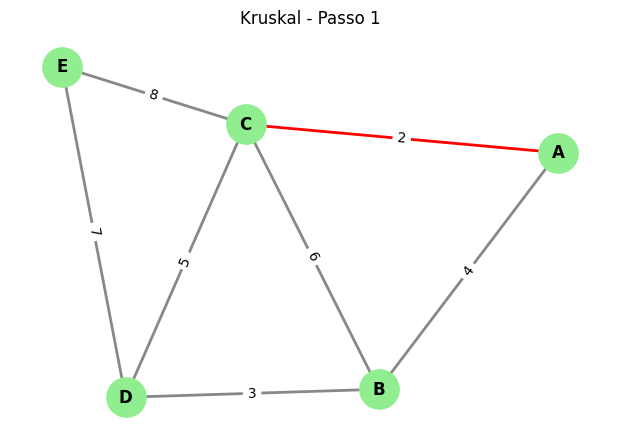

```
Passo 2:
  Considerando aresta (B, D) de custo 3
  -> Aresta adicionada à árvore geradora mínima.
  Vetor de chave: {'A': 2, 'B': 3, 'C': 2, 'D': 3, 'E': inf}
  Vetor de predecessor: {'A': 'C', 'B': 'D', 'C': 'A', 'D': 'B', 'E': None}
```

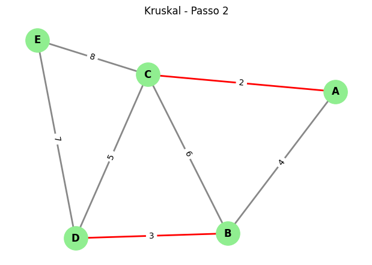

```
Passo 3:
  Considerando aresta (A, B) de custo 4
  -> Aresta adicionada à árvore geradora mínima.
  Vetor de chave: {'A': 2, 'B': 3, 'C': 2, 'D': 3, 'E': inf}
  Vetor de predecessor: {'A': 'C', 'B': 'D', 'C': 'A', 'D': 'B', 'E': None}
```

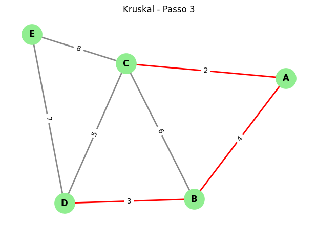

```
Passo 4:
  Considerando aresta (C, D) de custo 5
  -> Aresta descartada (formaria ciclo).
  Vetor de chave: {'A': 2, 'B': 3, 'C': 2, 'D': 3, 'E': inf}
  Vetor de predecessor: {'A': 'C', 'B': 'D', 'C': 'A', 'D': 'B', 'E': None}
```

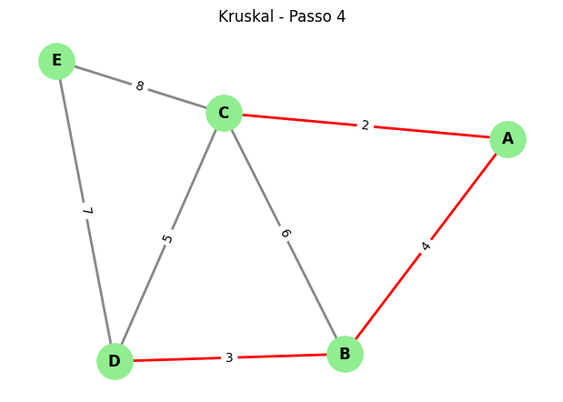

```
Passo 5:
  Considerando aresta (B, C) de custo 6
  -> Aresta descartada (formaria ciclo).
  Vetor de chave: {'A': 2, 'B': 3, 'C': 2, 'D': 3, 'E': inf}
  Vetor de predecessor: {'A': 'C', 'B': 'D', 'C': 'A', 'D': 'B', 'E': None}
```

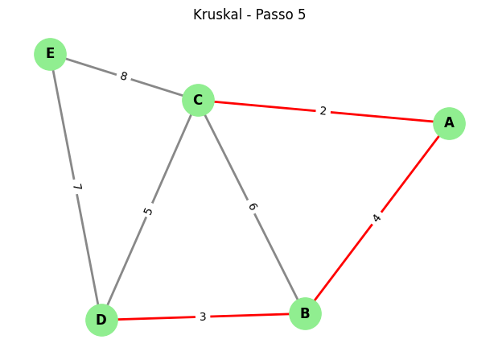

```
Passo 6:
  Considerando aresta (D, E) de custo 7
  -> Aresta adicionada à árvore geradora mínima.
  Vetor de chave: {'A': 2, 'B': 3, 'C': 2, 'D': 3, 'E': 7}
  Vetor de predecessor: {'A': 'C', 'B': 'D', 'C': 'A', 'D': 'B', 'E': 'D'}
```

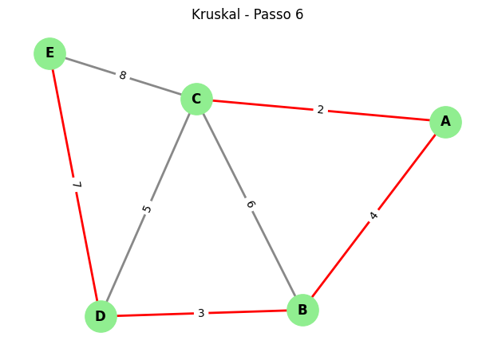

```
Custo total mínimo para conectar todos os bairros: 16
Vetor de chave final: {'A': 2, 'B': 3, 'C': 2, 'D': 3, 'E': 7}
Vetor de predecessor final: {'A': 'C', 'B': 'D', 'C': 'A', 'D': 'B', 'E': 'D'}
```

```python
# Resolvendo a árvore geradora mínima passo a passo com Kruskal

import networkx as nx
import matplotlib.pyplot as plt

# Criação do grafo ponderado
G_kruskal = nx.Graph()
G_kruskal.add_weighted_edges_from([
    ('A', 'B', 4),
    ('A', 'C', 2),
    ('B', 'C', 6),
    ('B', 'D', 3),
    ('C', 'D', 5),
    ('C', 'E', 8),
    ('D', 'E', 7)
])

# Algoritmo de Kruskal passo a passo com vetor de chave e predecessor (passos detalhados)
edges_sorted = sorted(G_kruskal.edges(data=True), key=lambda x: x[2]['weight'])
mst_edges = []
mst_cost = 0
uf = nx.utils.UnionFind()
passo = 1

chave = {v: float('inf') for v in G_kruskal.nodes}
predecessor = {v: None for v in G_kruskal.nodes}

pos = nx.spring_layout(G_kruskal, seed=42)

print("Início do algoritmo de Kruskal:")
print(f"  Vetor de chave inicial: {chave}")
print(f"  Vetor de predecessor inicial: {predecessor}\n")

for u, v, data in edges_sorted:
    print(f"Passo {passo}:")
    print(f"  Considerando aresta ({u}, {v}) de custo {data['weight']}")
    if uf[u] != uf[v]:
        print(f"  -> Aresta adicionada à árvore geradora mínima.")
        mst_edges.append((u, v))
        mst_cost += data['weight']
        uf.union(u, v)

        # Atualiza chave e predecessor para ambos os vértices da aresta
        if chave[v] > data['weight']:
            chave[v] = data['weight']
            predecessor[v] = u
        if chave[u] > data['weight']:
            chave[u] = data['weight']
            predecessor[u] = v
    else:
        print(f"  -> Aresta descartada (formaria ciclo).")

    print(f"  Vetor de chave: {chave}")
    print(f"  Vetor de predecessor: {predecessor}")

    # Visualização do grafo parcial da árvore geradora mínima
    edge_colors = []
    for e in G_kruskal.edges:
        if e in mst_edges or (e[1], e[0]) in mst_edges:
            edge_colors.append('red')
        else:
            edge_colors.append('#888')
    plt.figure(figsize=(6,4))
    nx.draw(
        G_kruskal, pos, with_labels=True,
        node_color='lightgreen', node_size=800, font_weight='bold',
        edge_color=edge_colors, width=2
    )
    labels = nx.get_edge_attributes(G_kruskal, 'weight')
    nx.draw_networkx_edge_labels(G_kruskal, pos, edge_labels=labels)
    plt.title(f"Kruskal - Passo {passo}")
    plt.show()
    print()
    passo += 1

    # Parar quando a árvore tiver n-1 arestas
    if len(mst_edges) == len(G_kruskal.nodes) - 1:
        break

print(f"Custo total mínimo para conectar todos os bairros: {mst_cost}")
print("Vetor de chave final:", chave)
print("Vetor de predecessor final:", predecessor)
```

### Explicação

O algoritmo de Kruskal constrói a árvore geradora mínima escolhendo sempre a aresta de menor custo que não forma ciclo, até conectar todos os vértices.

**Passo a passo:**

- Ordenamos as arestas pelo custo.
- Adicionamos as menores arestas, evitando ciclos, até conectar todos os bairros.
- A cada passo, mostramos o grafo parcial da árvore geradora mínima.

O custo total mínimo é a soma dos custos das arestas selecionadas. Assim, garantimos a conexão de todos os bairros com o menor custo possível.

## Algoritmo de Prim

O **algoritmo de Prim** é utilizado para encontrar a **árvore geradora mínima** (AGM) de um grafo ponderado e conexo. A AGM conecta todos os vértices do grafo com o menor custo total possível, sem formar ciclos.

### Como funciona o Prim?

1. **Escolha um vértice inicial** e marque-o como pertencente à AGM.
2. Entre todas as arestas que ligam um vértice da AGM a um vértice fora dela, **escolha a aresta de menor peso**.
3. Adicione o novo vértice e a aresta à AGM.
4. Repita o processo até que todos os vértices estejam na AGM.

### Características

- Sempre expande a árvore a partir dos vértices já incluídos, escolhendo a aresta mais barata disponível.
- Utiliza um vetor de chaves (custos mínimos) e um vetor de predecessores para controlar a expansão.
- Garante que não há ciclos e que o custo total é mínimo.

### Exemplo de aplicação

- Projetos de redes de computadores, energia ou estradas, onde se deseja conectar todos os pontos com o menor custo possível.

**Resumo:**  
O algoritmo de Prim constrói a árvore geradora mínima de forma incremental, sempre escolhendo a aresta de menor custo que conecta um novo vértice à árvore já formada.

```
Passo 0:
  Chave: {'S': 0, 'A': inf, 'C': inf, 'D': inf, 'B': inf}
  Predecessor: {'S': None, 'A': None, 'C': None, 'D': None, 'B': None}
  Conjunto da AGM: {'S': False, 'A': False, 'C': False, 'D': False, 'B': False}
```

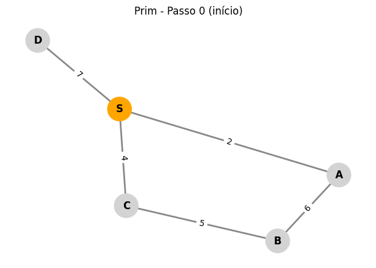

```
Passo 1:
  Vértice escolhido: S (chave=0)
  Chave antes: {'S': 0, 'A': inf, 'C': inf, 'D': inf, 'B': inf}
  Predecessor antes: {'S': None, 'A': None, 'C': None, 'D': None, 'B': None}
  Chave depois: {'S': 0, 'A': 2, 'C': 4, 'D': 7, 'B': inf}
  Predecessor depois: {'S': None, 'A': 'S', 'C': 'S', 'D': 'S', 'B': None}
  Conjunto da AGM: {'S': True, 'A': False, 'C': False, 'D': False, 'B': False}
```

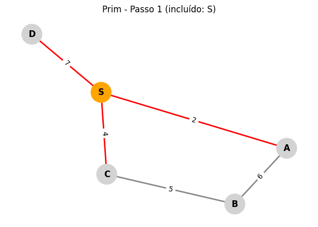

```
Passo 2:
  Vértice escolhido: A (chave=2)
  Chave antes: {'S': 0, 'A': 2, 'C': 4, 'D': 7, 'B': inf}
  Predecessor antes: {'S': None, 'A': 'S', 'C': 'S', 'D': 'S', 'B': None}
  Chave depois: {'S': 0, 'A': 2, 'C': 4, 'D': 7, 'B': 6}
  Predecessor depois: {'S': None, 'A': 'S', 'C': 'S', 'D': 'S', 'B': 'A'}
  Conjunto da AGM: {'S': True, 'A': True, 'C': False, 'D': False, 'B': False}
```

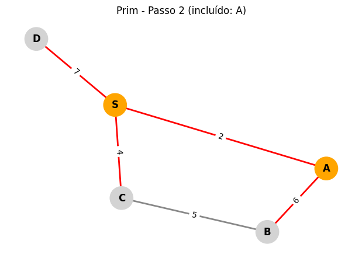

```
Passo 3:
  Vértice escolhido: C (chave=4)
  Chave antes: {'S': 0, 'A': 2, 'C': 4, 'D': 7, 'B': 6}
  Predecessor antes: {'S': None, 'A': 'S', 'C': 'S', 'D': 'S', 'B': 'A'}
  Chave depois: {'S': 0, 'A': 2, 'C': 4, 'D': 7, 'B': 5}
  Predecessor depois: {'S': None, 'A': 'S', 'C': 'S', 'D': 'S', 'B': 'C'}
  Conjunto da AGM: {'S': True, 'A': True, 'C': True, 'D': False, 'B': False}
```

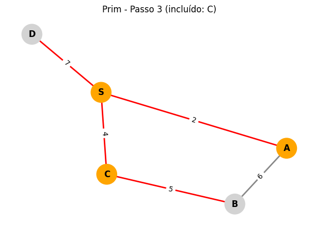

```
Passo 4:
  Vértice escolhido: B (chave=5)
  Chave antes: {'S': 0, 'A': 2, 'C': 4, 'D': 7, 'B': 5}
  Predecessor antes: {'S': None, 'A': 'S', 'C': 'S', 'D': 'S', 'B': 'C'}
  Chave depois: {'S': 0, 'A': 2, 'C': 4, 'D': 7, 'B': 5}
  Predecessor depois: {'S': None, 'A': 'S', 'C': 'S', 'D': 'S', 'B': 'C'}
  Conjunto da AGM: {'S': True, 'A': True, 'C': True, 'D': False, 'B': True}
```

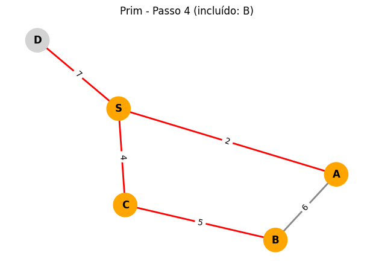

```
Passo 5:
  Vértice escolhido: D (chave=7)
  Chave antes: {'S': 0, 'A': 2, 'C': 4, 'D': 7, 'B': 5}
  Predecessor antes: {'S': None, 'A': 'S', 'C': 'S', 'D': 'S', 'B': 'C'}
  Chave depois: {'S': 0, 'A': 2, 'C': 4, 'D': 7, 'B': 5}
  Predecessor depois: {'S': None, 'A': 'S', 'C': 'S', 'D': 'S', 'B': 'C'}
  Conjunto da AGM: {'S': True, 'A': True, 'C': True, 'D': True, 'B': True}
```

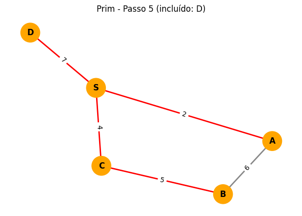

```
Resultado final da AGM (Prim):
Chave: {'S': 0, 'A': 2, 'C': 4, 'D': 7, 'B': 5}
Predecessor: {'S': None, 'A': 'S', 'C': 'S', 'D': 'S', 'B': 'C'}
Arestas da AGM: [('S', 'A'), ('S', 'C'), ('S', 'D'), ('C', 'B')]
Custo total: 18
```

```python
# Questão: AGM com Prim passo a passo (com chaves e predecessores)

import networkx as nx
import matplotlib.pyplot as plt

# Criação do grafo ponderado
G_prim = nx.Graph()
G_prim.add_weighted_edges_from([
    ('S', 'A', 2),
    ('S', 'C', 4),
    ('S', 'D', 7),
    ('A', 'B', 6),
    ('C', 'B', 5)
])

vertices = list(G_prim.nodes)
raiz = 'S'
chave = {v: float('inf') for v in vertices}
predecessor = {v: None for v in vertices}
in_mst = {v: False for v in vertices}

chave[raiz] = 0

pos = nx.spring_layout(G_prim, seed=42)

print("Passo 0:")
print(f"  Chave: {chave}")
print(f"  Predecessor: {predecessor}")
print(f"  Conjunto da AGM: {in_mst}\n")
plt.figure(figsize=(6,4))
nx.draw(
    G_prim, pos, with_labels=True,
    node_color=['orange' if n == raiz else 'lightgray' for n in G_prim.nodes],
    node_size=800, font_weight='bold',
    edge_color='#888', width=2
)
labels = nx.get_edge_attributes(G_prim, 'weight')
nx.draw_networkx_edge_labels(G_prim, pos, edge_labels=labels)
plt.title("Prim - Passo 0 (início)")
plt.show()

for passo in range(1, len(vertices)+1):
    # Escolhe o vértice de menor chave fora da AGM
    u = min((v for v in vertices if not in_mst[v]), key=lambda v: chave[v])
    in_mst[u] = True

    print(f"Passo {passo}:")
    print(f"  Vértice escolhido: {u} (chave={chave[u]})")
    print(f"  Chave antes: {chave}")
    print(f"  Predecessor antes: {predecessor}")

    # Atualiza as chaves dos vizinhos
    for v in G_prim.neighbors(u):
        peso = G_prim[u][v]['weight']
        if not in_mst[v] and peso < chave[v]:
            chave[v] = peso
            predecessor[v] = u

    print(f"  Chave depois: {chave}")
    print(f"  Predecessor depois: {predecessor}")
    print(f"  Conjunto da AGM: {in_mst}\n")

    # Plot do passo
    edge_colors = []
    for e in G_prim.edges:
        if (predecessor[e[1]] == e[0]) or (predecessor[e[0]] == e[1]):
            edge_colors.append('red')
        else:
            edge_colors.append('#888')
    node_colors = ['orange' if in_mst[n] else 'lightgray' for n in G_prim.nodes]

    plt.figure(figsize=(6,4))
    nx.draw(
        G_prim, pos, with_labels=True,
        node_color=node_colors, node_size=800, font_weight='bold',
        edge_color=edge_colors, width=2
    )
    nx.draw_networkx_edge_labels(G_prim, pos, edge_labels=labels)
    plt.title(f"Prim - Passo {passo} (incluído: {u})")
    plt.show()

print("Resultado final da AGM (Prim):")
print("Chave:", chave)
print("Predecessor:", predecessor)
print("Arestas da AGM:", [(predecessor[v], v) for v in vertices if predecessor[v] is not None])
print("Custo total:", sum(chave.values()))
```

### Explicação

O algoritmo de Prim constrói a árvore geradora mínima a partir de um vértice inicial, sempre escolhendo a aresta de menor custo que expande a árvore até conectar todos os vértices.

**Passo a passo:**

- Começamos com um vértice inicial (raiz) e vamos adicionando vértices à árvore.
- A cada passo, escolhemos o vértice de menor chave que não está na árvore e atualizamos as chaves dos seus vizinhos.
- O processo se repete até que todos os vértices estejam na árvore.

O custo total mínimo é a soma dos custos das arestas da árvore geradora mínima.

### Questão 6: AGM com Kruskal passo a passo (com plot e prints)

Uma empresa deseja conectar 4 de suas filiais (A, B, C, D) utilizando o menor comprimento de cabos possível. As distâncias entre as filiais são as seguintes:

- A - B: 1
- A - C: 4
- B - C: 2
- B - D: 5
- C - D: 3

Utilize o algoritmo de Kruskal para determinar o comprimento mínimo de cabo necessário e quais filiais estarão conectadas.

## Algoritmo de Kruskal

O **algoritmo de Kruskal** é um método para encontrar a **árvore geradora mínima** (AGM) de um grafo ponderado e conexo. A AGM conecta todos os vértices do grafo com o menor custo total possível, sem formar ciclos.

### Como funciona o Kruskal?

1. **Ordena todas as arestas** do grafo em ordem crescente de peso (custo).
2. **Inicializa** a AGM como um conjunto vazio.
3. Para cada aresta, na ordem dos menores pesos:
   - Se a aresta **não formar um ciclo** ao ser adicionada à AGM, inclua-a.
   - Caso contrário, descarte a aresta.
4. Repita até que a AGM tenha exatamente $n-1$ arestas (onde $n$ é o número de vértices).

### Características

- Sempre escolhe a aresta mais barata disponível que não forma ciclo.
- Utiliza uma estrutura chamada **Union-Find** para detectar ciclos de forma eficiente.
- Funciona para grafos conexos e florestas.

### Exemplo de aplicação

- Projetos de redes de computadores, energia ou estradas, onde se deseja conectar todos os pontos com o menor custo possível.

**Resumo:**  
O algoritmo de Kruskal constrói a árvore geradora mínima escolhendo sempre as arestas de menor peso, evitando ciclos, até conectar todos os vértices.

```
Passo 0: Estado inicial do grafo (nenhuma aresta selecionada)
```

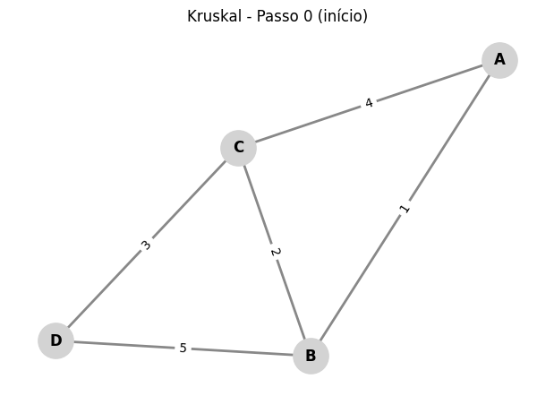

```
Passo 1:
  Considerando aresta (A, B) de custo 1
  -> Aresta adicionada à AGM.
```

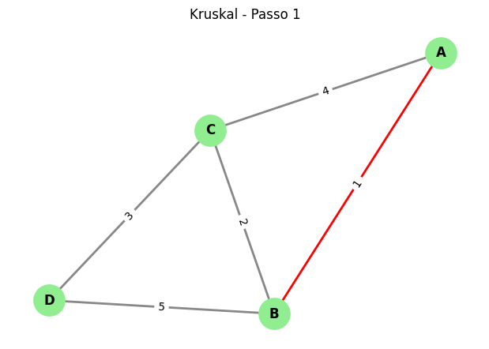

```
  Arestas na AGM até agora: [('A', 'B')]
  Custo parcial: 1

Passo 2:
  Considerando aresta (B, C) de custo 2
  -> Aresta adicionada à AGM.
```

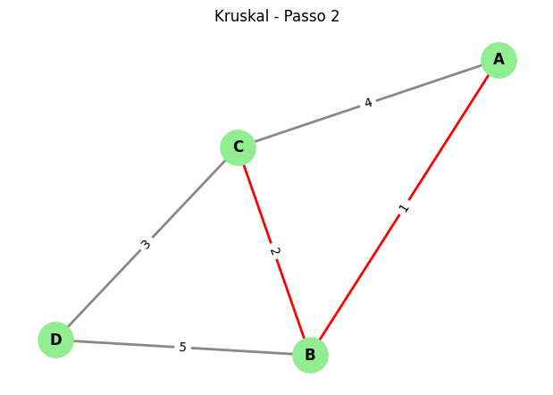

```
  Arestas na AGM até agora: [('A', 'B'), ('B', 'C')]
  Custo parcial: 3

Passo 3:
  Considerando aresta (C, D) de custo 3
  -> Aresta adicionada à AGM.
```

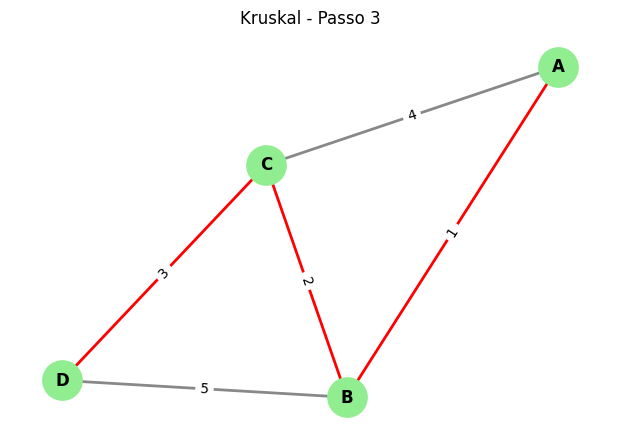

```
  Arestas na AGM até agora: [('A', 'B'), ('B', 'C'), ('C', 'D')]
  Custo parcial: 6

Resultado final da AGM (Kruskal):
Arestas selecionadas: [('A', 'B'), ('B', 'C'), ('C', 'D')]
Custo total: 6
```

```python
# Questão 6: AGM com Kruskal passo a passo (com plot e prints)

import networkx as nx
import matplotlib.pyplot as plt

# Criação do grafo ponderado
G_kruskal2 = nx.Graph()
G_kruskal2.add_weighted_edges_from([
    ('A', 'B', 1),
    ('A', 'C', 4),
    ('B', 'C', 2),
    ('B', 'D', 5),
    ('C', 'D', 3)
])

edges_sorted = sorted(G_kruskal2.edges(data=True), key=lambda x: x[2]['weight'])
mst_edges = []
mst_cost = 0
uf = nx.utils.UnionFind()
passo = 0

pos = nx.spring_layout(G_kruskal2, seed=42)

print(f"Passo {passo}: Estado inicial do grafo (nenhuma aresta selecionada)")
plt.figure(figsize=(6,4))
nx.draw(
    G_kruskal2, pos, with_labels=True,
    node_color='lightgray', node_size=800, font_weight='bold',
    edge_color='#888', width=2
)
labels = nx.get_edge_attributes(G_kruskal2, 'weight')
nx.draw_networkx_edge_labels(G_kruskal2, pos, edge_labels=labels)
plt.title("Kruskal - Passo 0 (início)")
plt.show()
passo += 1

for u, v, data in edges_sorted:
    print(f"Passo {passo}:")
    print(f"  Considerando aresta ({u}, {v}) de custo {data['weight']}")
    if uf[u] != uf[v]:
        print(f"  -> Aresta adicionada à AGM.")
        mst_edges.append((u, v))
        mst_cost += data['weight']
        uf.union(u, v)
    else:
        print(f"  -> Aresta descartada (formaria ciclo).")

    # Visualização do grafo parcial da AGM
    edge_colors = []
    for e in G_kruskal2.edges:
        if e in mst_edges or (e[1], e[0]) in mst_edges:
            edge_colors.append('red')
        else:
            edge_colors.append('#888')
    plt.figure(figsize=(6,4))
    nx.draw(
        G_kruskal2, pos, with_labels=True,
        node_color='lightgreen', node_size=800, font_weight='bold',
        edge_color=edge_colors, width=2
    )
    nx.draw_networkx_edge_labels(G_kruskal2, pos, edge_labels=labels)
    plt.title(f"Kruskal - Passo {passo}")
    plt.show()
    print(f"  Arestas na AGM até agora: {mst_edges}")
    print(f"  Custo parcial: {mst_cost}\n")
    passo += 1

    # Parar quando a AGM tiver n-1 arestas
    if len(mst_edges) == len(G_kruskal2.nodes) - 1:
        break

print("Resultado final da AGM (Kruskal):")
print("Arestas selecionadas:", mst_edges)
print("Custo total:", mst_cost)
```

### Explicação

Neste exercício, aplicamos o algoritmo de Kruskal para encontrar a árvore geradora mínima (AGM) de um grafo ponderado que representa as distâncias entre filiais de uma empresa.

**Passo a passo:**

- O algoritmo começa ordenando as arestas do grafo pelo seu peso (custo).
- Em seguida, ele adiciona as arestas uma a uma à AGM, começando pela de menor peso, desde que não formem um ciclo.
- O processo continua até que todas as filiais estejam conectadas.

**Resultado:**  
A AGM encontrada é a que conecta todas as filiais com o menor comprimento total de cabos, garantindo a economia e eficiência na instalação da rede de filiais da empresa.

### Questão 7: Menor custo entre todos os pares (Floyd-Warshall passo a passo)

Uma empresa deseja analisar o custo mínimo de transporte entre todas as suas filiais, considerando as distâncias diretas entre elas. As filiais e as distâncias são as seguintes:

- A → B: 3
- A → C: 10
- B → C: 1
- B → D: 2
- C → D: 4

Utilize o algoritmo de Floyd-Warshall para determinar a matriz de custos mínimos entre todas as filiais. Mostre o passo a passo do algoritmo, explicando o que acontece em cada iteração/intermediário.